# This is the data merging and checking file

This is file that loads all the raw data from the Jibbon root trait project. Then it stickes the datasets together and does a bunch of checks looking for:

1. Missing data
2. Duplicate data
3. Outliers
4. Spelling mistakes

Loading all the data

```r
library(tidyverse)
library(plotly)
library(lme4)
air_porosity <- read_csv("data/air_porosity_complete.csv")
cluster_root_weight <- read_csv("data/cluster_root_weight_data_complete.csv")
dry_root_weight_1 <- read_csv("data/tissue_density_SRL_1.csv")
dry_root_weight_2 <- read_csv("data/tissue_density_SRL_2.csv")
root_length_data <- read_csv("data/branching_intensity_srl_lenght_complete.csv")
soil_moisture <- read_csv("data/Soil_Moisture.csv")
names(soil_moisture)[5]<-"SoilMoistureContent"
```

assemble mass data from two different files and make a column in the mass data set that is the unique id for matching

```r
bind_rows(dry_root_weight_1,dry_root_weight_2) %>%
  mutate(unique_id=paste0(site,sample,species,replicate)) %>%
  gather(key=type_of_data,value = mass_measurement,SRL,TD) -> mass_data_gathered
```

Are there any duplicates for SRL?

```r
srl.mass.data<-filter(mass_data_gathered, type_of_data=="SRL", !is.na(mass_measurement) )
head(sort(table(srl.mass.data$unique_id),decreasing = TRUE))
```

```
##
##      S10S1Banksia ericifolia1         S10S1Empodisma minus1
##                             1                             1
##       S10S1Entolasia stricta1   S10S1Gonocarpus micranthus1
##                             1                             1
##     S10S1Lepidosperma neesii1 S10S1Leptospermum squarrosum1
##                             1                             1
```

```r
out<-filter(srl.mass.data,unique_id=="S20S2Ptilothrix deusta2")
```

Are there any duplicates for TD?

```r
td.mass.data<-filter(mass_data_gathered, type_of_data=="TD", !is.na(mass_measurement) )
head(sort(table(td.mass.data$unique_id),decreasing = TRUE))
```

```
##
##      S10S1Banksia ericifolia1         S10S1Empodisma minus1
##                             1                             1
##       S10S1Entolasia stricta1   S10S1Gonocarpus micranthus1
##                             1                             1
##     S10S1Lepidosperma neesii1 S10S1Leptospermum squarrosum1
##                             1                             1
```

```r
out<-filter(td.mass.data,unique_id=="S3S3Leptocarpus tenax3")
```

make a column in the root length set that is the unique id for matching and check for duplicates

```r
root_length_data$unique_id<-paste0(root_length_data$site,root_length_data$sample,root_length_data$species,root_length_data$replicate)
sum(table(root_length_data$unique_id)>1)
```

```
## [1] 0
```

Unique IDs in mass data that don’t match the root length data

```r
srl.mass.data$unique_id[!srl.mass.data$unique_id %in% root_length_data$unique_id]
```

```
## character(0)
```

Things in root length data that don’t match the mass data.

```r
root_length_data$unique_id[!root_length_data$unique_id %in% srl.mass.data$unique_id]
```

```
## character(0)
```

Then we match everything up and calculate SRL

```r
inner_join(srl.mass.data,root_length_data,by="unique_id") %>%
  mutate(specific_root_length=Length_cm/mass_measurement) -> SRL.DF
```

Checking the outliers

```r
arrange(SRL.DF,desc(specific_root_length)) %>%
  select(unique_id=unique_id,mass=mass_measurement,Length_cm=Length_cm,srl=specific_root_length)->SRL.DF.ORDERED

SRL.DF.ORDERED[1:10,]
```

```
## # A tibble: 10 x 4
##                        unique_id  mass Length_cm      srl
##                            <chr> <dbl>     <dbl>    <dbl>
## 1        S3S1Lepyrodia scariosa1 3e-04    11.215 37383.33
## 2   S3S1Plinthanthesis paradoxa1 7e-04    18.656 26651.43
## 3        S13S3Caustis pentandra3 2e-04     5.053 25265.00
## 4  S19S3Leptospermum squarrosum3 2e-04     3.424 17120.00
## 5     S6S3Gonocarpus micranthus3 6e-04     8.848 14746.67
## 6    S14S2Gonocarpus micranthus2 5e-04     6.512 13024.00
## 7    S18S1Gonocarpus micranthus1 4e-04     4.866 12165.00
## 8       S19S1Lepyrodia scariosa1 3e-04     3.610 12033.33
## 9  S14S1Leptospermum squarrosum1 3e-04     3.604 12013.33
## 10       S13S2Caustis pentandra2 6e-04     6.739 11231.67
```

```r
arrange(SRL.DF,specific_root_length) %>%
  select(unique_id=unique_id,mass=mass_measurement,Length_cm=Length_cm,srl=specific_root_length)->SRL.DF.ORDERED

SRL.DF.ORDERED[1:10,]
```

```
## # A tibble: 10 x 4
##                        unique_id   mass Length_cm      srl
##                            <chr>  <dbl>     <dbl>    <dbl>
## 1        S20S1Ptilothrix deusta1 0.0192    2.9911 155.7865
## 2       S20S2Banksia ericifolia2 0.0273    5.0550 185.1648
## 3        S15S1Ptilothrix deusta1 0.0454    8.7140 191.9383
## 4           S9S2Xyris bracteata2 0.0284    5.9500 209.5070
## 5          S20S3Empodisma minus3 0.0301    6.4350 213.7874
## 6          S4S2Lomandra obliqua2 0.0377    8.3610 221.7772
## 7         S14S2Lomandra obliqua2 0.0189    4.2410 224.3915
## 8    S8S2Haemodorum planifolium2 0.0435    9.7960 225.1954
## 9  S13S2Plinthanthesis paradoxa2 0.0185    4.9720 268.7568
## 10       S18S1Ptilothrix deusta1 0.0229    6.1700 269.4323
```

Let’s calculate density.

Checking for duplicate samples

```r
air_porosity$unique_id<-paste0(air_porosity$site,air_porosity$sample,air_porosity$species,air_porosity$replicate)
out<-sort(table(air_porosity$unique_id),decreasing = TRUE)
out[out>1]
```

```
## named integer(0)
```

```r
out<-filter(air_porosity,unique_id=="S14S2Lepidosperma neesii2")
```

```r
air_porosity$unique_id[!air_porosity$unique_id %in% td.mass.data$unique_id]
```

```
## character(0)
```

```r
td.mass.data$unique_id[!td.mass.data$unique_id %in% air_porosity$unique_id]
```

```
## character(0)
```

Calculate density:

```r
inner_join(air_porosity,td.mass.data,by=c("site", "sample","species")) %>%
  select(site,sample,species,root_volume,mass_measurement) %>%
  mutate(density=mass_measurement/root_volume)-> density.df
```

Check for missing values either for volume or for mass

```r
density_missing_data<-filter(density.df,is.na(density))
```

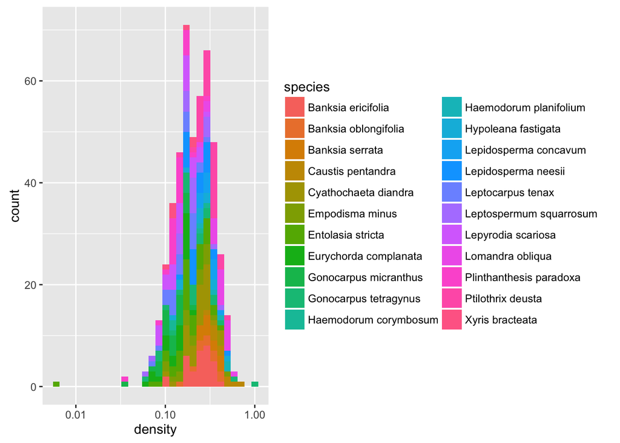

```r
gg<-ggplot(density.df,aes(x=density,fill=species))+geom_histogram()+scale_x_log10()
gg
```

Checking for outliers:

```r
arrange(density.df,density)
```

```
## # A tibble: 467 x 6
##     site sample                 species root_volume mass_measurement
##    <chr>  <chr>                   <chr>       <dbl>            <dbl>
## 1     S7     S1       Entolasia stricta  0.89108216           0.0051
## 2     S7     S2 Plinthanthesis paradoxa  0.18707415           0.0061
## 3     S7     S1   Gonocarpus micranthus  0.12955912           0.0044
## 4     S4     S2   Gonocarpus tetragynus  0.09649299           0.0055
## 5     S7     S3 Leptospermum squarrosum  0.08867735           0.0053
## 6     S7     S2   Eurychorda complanata  0.40140281           0.0254
## 7     S3     S1       Leptocarpus tenax  0.69488978           0.0486
## 8     S5     S3   Gonocarpus micranthus  0.37434870           0.0272
## 9     S7     S2 Leptospermum squarrosum  0.08747495           0.0064
## 10    S7     S3   Eurychorda complanata  0.12384769           0.0092
## # ... with 457 more rows, and 1 more variables: density <dbl>
```

```r
arrange(density.df,desc(density))
```

```
## # A tibble: 467 x 6
##     site sample               species root_volume mass_measurement
##    <chr>  <chr>                 <chr>       <dbl>            <dbl>
## 1    S18     S3 Gonocarpus tetragynus  0.05661323           0.0536
## 2    S12     S2     Caustis pentandra  0.63456914           0.4242
## 3    S11     S1     Caustis pentandra  1.50831663           0.8888
## 4     S4     S2      Lomandra obliqua  0.24579158           0.1346
## 5    S19     S3 Gonocarpus tetragynus  0.02975952           0.0162
## 6     S6     S3   Lepidosperma neesii  0.12725451           0.0680
## 7    S12     S2   Hypoleana fastigata  0.30050100           0.1565
## 8     S8     S3      Lomandra obliqua  0.52284569           0.2682
## 9    S19     S2     Ptilothrix deusta  0.53977956           0.2746
## 10   S15     S2      Lomandra obliqua  0.08597194           0.0427
## # ... with 457 more rows, and 1 more variables: density <dbl>
```

### Air porosity

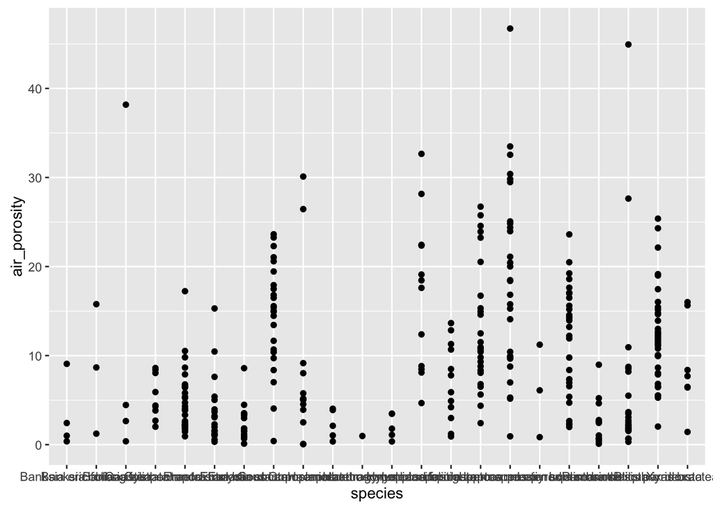

```r
filter(air_porosity,air_porosity>0) %>%
ggplot(aes(y=air_porosity,x=species))+geom_point()
```

```r
filter(air_porosity,air_porosity>0) %>%
  group_by(species) %>%
  summarize(mean(air_porosity))%>%
  knitr::kable(digits=2)
```

| species | mean(air_porosity) |
| --- | --- |
| Banksia ericifolia | 3.22 |
| Banksia oblongifolia | 8.56 |
| Banksia serrata | 11.41 |
| Caustis pentandra | 5.36 |
| Cyathochaeta diandra | 4.87 |
| Empodisma minus | 3.85 |
| Entolasia stricta | 2.51 |
| Eurychorda complanata | 14.59 |
| Gonocarpus micranthus | 7.93 |
| Gonocarpus tetragynus | 2.29 |
| Haemodorum corymbosum | 0.97 |
| Haemodorum planifolium | 2.04 |
| Hypoleana fastigata | 16.93 |
| Lepidosperma concavum | 7.07 |
| Lepidosperma neesii | 13.11 |
| Leptocarpus tenax | 18.86 |
| Leptospermum squarrosum | 6.06 |
| Lepyrodia scariosa | 11.93 |
| Lomandra obliqua | 2.52 |
| Plinthanthesis paradoxa | 6.80 |
| Ptilothrix deusta | 12.08 |
| Xyris bracteata | 8.87 |

Possible ones that are crazy

```r
filter(air_porosity,air_porosity>35)
```

```
## # A tibble: 3 x 18
##    site sample site_class                 species species_code replicate
##   <chr>  <chr>      <chr>                   <chr>        <chr>     <int>
## 1   S18     S2         IB       Leptocarpus tenax        tenax         2
## 2    S7     S2         BW Plinthanthesis paradoxa         plin         2
## 3    S8     S3         BD         Banksia serrata         Serr         3
## # ... with 12 more variables: fresh_mass_of_roots <dbl>,
## #   Mass_of_pycnometer_filled_with_water <dbl>,
## #   temperature_of_water_reading_1 <dbl>, density_1 <dbl>,
## #   fresh_weight_pycnometer_with_roots_and_water_before_vaccuum <dbl>,
## #   temp_of_water_reading_2 <dbl>, density_2 <dbl>,
## #   fresh_weight_pycnometer_after_vacuum <dbl>, root_volume <dbl>,
## #   air_root_volume <dbl>, air_porosity <dbl>, unique_id <chr>
```

### Number of tips

```r
root_length_data<- mutate(root_length_data,rbi=Number_of_tips/Length_cm)

filter(root_length_data,rbi>7)
```

```
## # A tibble: 1 x 10
##    site sample site_class           species species_code replicate
##   <chr>  <chr>      <chr>             <chr>        <chr>     <int>
## 1   S20     S3         IB Ptilothrix deusta          pti         3
## # ... with 4 more variables: Length_cm <dbl>, Number_of_tips <int>,
## #   unique_id <chr>, rbi <dbl>
```

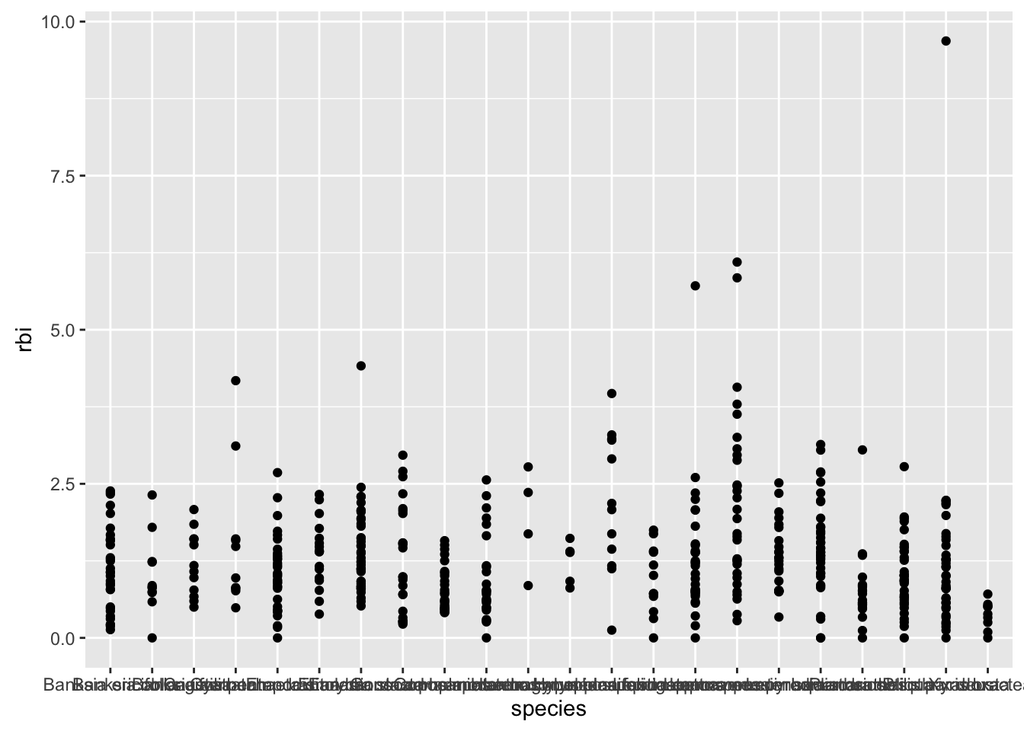

```r
ggplot(root_length_data,aes(y=rbi,x=species))+geom_point()
```

```r
filter(root_length_data,rbi<7) %>%
  group_by(species) %>%
  summarize(mean.rbi=mean(rbi))%>%
  arrange(mean.rbi)%>%
  knitr::kable(digits=2)
```

| species | mean.rbi |
| --- | --- |
| Xyris bracteata | 0.37 |
| Lomandra obliqua | 0.78 |
| Gonocarpus micranthus | 0.82 |
| Lepidosperma concavum | 0.94 |
| Gonocarpus tetragynus | 0.97 |
| Banksia oblongifolia | 1.01 |
| Cyathochaeta diandra | 1.02 |
| Ptilothrix deusta | 1.03 |
| Plinthanthesis paradoxa | 1.03 |
| Banksia ericifolia | 1.13 |
| Banksia serrata | 1.20 |
| Haemodorum planifolium | 1.23 |
| Eurychorda complanata | 1.25 |
| Lepidosperma neesii | 1.30 |
| Leptospermum squarrosum | 1.31 |
| Empodisma minus | 1.36 |
| Entolasia stricta | 1.43 |
| Lepyrodia scariosa | 1.50 |
| Caustis pentandra | 1.58 |
| Haemodorum corymbosum | 1.92 |
| Leptocarpus tenax | 2.16 |
| Hypoleana fastigata | 2.20 |

```r
test<-inner_join(soil_moisture,mass_data_gathered)
group_by(test,species)%>%
  summarize(median.OM=median(OM),cv.OM=sd(OM)/mean(OM))%>%
  arrange(median.OM) -> species_median_OM
```

## Assmbling the mega_csv

```r
root_length_data<- mutate(root_length_data,rbi=Number_of_tips/Length_cm)
srl.for.joining<-select(SRL.DF,site=site.x,sample=sample.x,species=species.x,srl=specific_root_length,unique_id)
density.df.for.joining<-select(density.df,site,sample,species,density)
root.length.data.for.joining<-select(root_length_data,site,sample,species,rbi)
air.porosity.for.joining<-select(air_porosity,site,sample,species,air_porosity)
mean.soil<-summarize(group_by(soil_moisture,site),som=median(OM),smc=median(SoilMoistureContent))

full_join(density.df.for.joining,root.length.data.for.joining) %>%
   full_join(srl.for.joining) %>%
  full_join(air.porosity.for.joining) %>%
    full_join(mean.soil) ->mass_df
  write_csv(mass_df,"mass_output.csv")
```

Now some plotting

this summarizes by species in a very complicated way because it’s calculating 10-90 quantile ranges for SOM and SMC and SE for density

then it does some ggplotting

```r
sane<-filter(mass_df,density>0.05,density<1)

  summarize(group_by(sane,species),som.median=median(som),density.mean=mean(density),som.quant1=quantile(som,0.5)-quantile(som,0.1),som.quant2=quantile(som,0.9)-quantile(som,0.5),density.se=sd(density,na.rm=TRUE)/sqrt(sum(!is.na(density))),smc.median=median(smc),smc.quant1=quantile(smc,0.5)-quantile(smc,0.1),smc.quant2=quantile(smc,0.9)-quantile(smc,0.5))->temp


  ggplot(temp,aes(x=som.median,y=density.mean,col=species))+
    geom_point()+
   geom_errorbarh(aes(xmin=som.median-som.quant1,xmax=som.median+som.quant2,y=density.mean))+
    geom_errorbar(aes(ymin=density.mean-density.se,ymax=density.mean+density.se))+theme_bw()+scale_x_log10(breaks=c(1:10))->gg

  ggplotly(gg)
```

[interactive chart not shown]

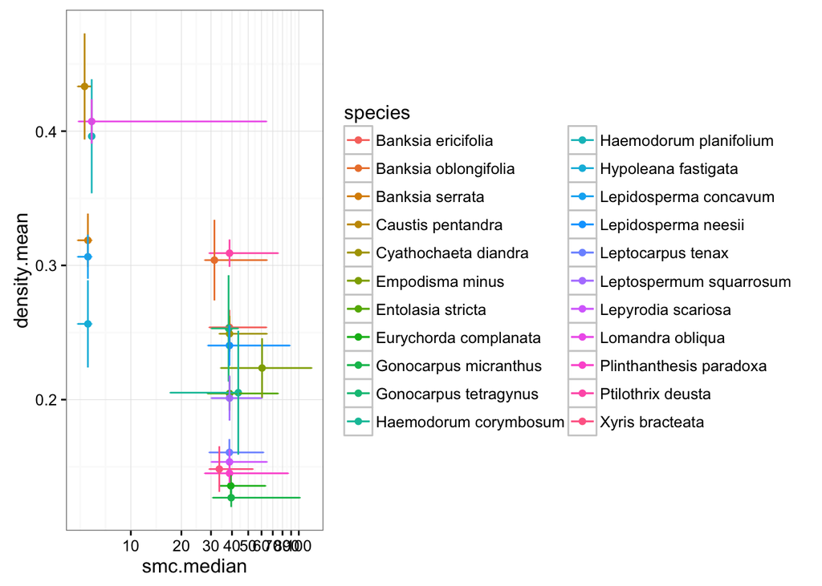

```r
  ggplot(temp,aes(x=smc.median,y=density.mean,col=species))+
    geom_point()+
   geom_errorbarh(aes(xmin=smc.median-smc.quant1,xmax=smc.median+smc.quant2,y=density.mean))+
    geom_errorbar(aes(ymin=density.mean-density.se,ymax=density.mean+density.se))+theme_bw()+scale_x_log10(breaks=seq(10,100,10))
```

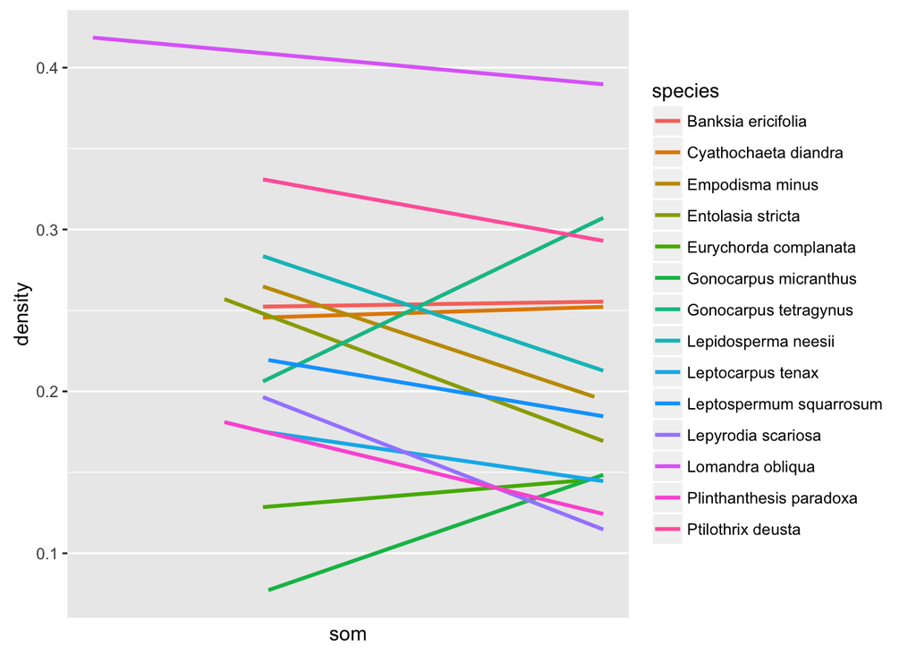

```r
    saner<-filter(sane,species%in%names(table(sane$species))[table(sane$species)>12])


   ggplot(saner,aes(x=som,y=density,col=species))+
     geom_smooth(method="lm",se=F)+scale_x_log10()
```

```r
  mod <- lmer(density ~ log(som) + (1|species),data = sane, REML=T)
  mod.0 <- lmer(density ~  (1|species),data = sane, REML=T)
  anova(mod,mod.0)
```

```
## refitting model(s) with ML (instead of REML)
```

```
## Data: sane
## Models:
## mod.0: density ~ (1 | species)
## mod: density ~ log(som) + (1 | species)
##       Df     AIC     BIC logLik deviance  Chisq Chi Df Pr(>Chisq)
## mod.0  3 -942.00 -929.58 474.00  -948.00
## mod    4 -950.37 -933.81 479.19  -958.37 10.369      1   0.001281 **
## ---
## Signif. codes:  0 '***' 0.001 '**' 0.01 '*' 0.05 '.' 0.1 ' ' 1
```

read [here](http://environmentalcomputing.net/mixed-models-1/)

for more